# SCN2A mutation

#1. Introduction

## 1.1. Background

SCN2A is a voltage-gated sodium channel gene that encodes the neuronal sodium channel NaV1.2 and plays a critical role in action potential initiation during early neurodevelopment. The latest study demonstrated that it is loss of function mutations that in SCN2A that lead to autism spectrum disorders (ASD), in contrast to gain of function, which leads to infantile seizures (Ben-Shalom 2018). In this tutorial, we will handle genetic data for SCN2A mutations identified in latest genomic studies, and then explore the data format to describe genetic mutations using R basic functions. Our tutorial will utilize the summary data from Sanders et al. (2018).

##1.2. Aims

What we will do with this dataset, Understand the dataset from a scientific journal Apply some functions you have learnt from the Chapter 2 and 3

#2. Explore your data

## 2.1. Unboxing your dataset

Here we obtain the list of mutations in the Supplementary Table 1 from Sanders et al. (2018). Using the rio package, reading the excel file from the file link into your workspace. If you don’t have the rio package in your system, please install as following:

```r
install.packages('rio')
```

```r
library(pander)
library(tidyverse)
```

Now you can read the file from the website. This will create the `d` object.

```r
library(rio)
d = rio::import('https://www.ncbi.nlm.nih.gov/pmc/articles/PMC6015533/bin/NIHMS957592-supplement-1.xlsx')
```

Let’s explore the object you just loaded. How would you check the class of the object `d`?

```r
class(d)
```

```
[1] "data.frame"
```

It shows that the `d` object is `data.frame.` Then, let’s overview the data frame. We will use `head` function to print out first few lines.

```r
head(d) %>%pander()
```

```
----------------------------------------------------------------------
  PatientID     PatientSex   PatientAgeAtAssessment   Chr   Pos_hg19
-------------- ------------ ------------------------ ----- -----------
      .             M                  7y              2    154370122

      .             F                  3y              2    163706754

   Patient2         F                 18m              2    163875903

 Case1,280269       F                  4y              2    165798270

      .             M                  3y              2    166019786

      .             F                 25y              2    166060054
----------------------------------------------------------------------

Table: Table continues below


---------------------------------------------------------------------------
    Ref             Alt          Type       Effect       c.DNA   p.Protein
----------- ------------------- ------ ---------------- ------- -----------
 166384278   12Mb Duplication    CNV    DuplicationCNV     .         .

 166506754    2.8Mb Deletion     CNV     DeletionCNV       .         .

 166478766   2.6Mb Duplication   CNV    DuplicationCNV     .         .

 166304847   507kb Duplication   CNV    DuplicationCNV     .         .

 166249879    230kb Deletion     CNV     DeletionCNV       .         .

 166153823     94kb Deletion     CNV     DeletionCNV       .         .
---------------------------------------------------------------------------

Table: Table continues below


-------------------------------------------------------------------------------
 Inheritence           Source          SourcePMID   Ben-Shalom2017   Wolff2017
```

[output cut: 57 more lines]

```
------------------------------ -----------------
          clumsiness            IEE_Mild/Ataxia

     dysmorphia, immature           ASD/DD
         myelination

       cerebral atrophy               IEE

              .                       BIS

         microcephaly               ASD/DD

 hypotonia, bipolar disorder,       ASD/DD
     behavioral problems
------------------------------------------------
```

When you execute code in a notebook chunk, an output will be visible immediately beneath the input. From this, you can see several rows and columns in the data frame. Let’s look at the first column `PatientID` and check which class it is.

```r
head(d$PatientID)
```

```
[1] "."            "."            "Patient2"
[4] "Case1,280269" "."            "."
```

Cool. Now you can see the `TrueRecurrence` column. What is the class of the column `TrueRecurrence`?

```r
class(d$TrueRecurrence)
```

```
[1] "numeric"
```

To check the class of columns, you don’t need to type an individual column. We can overview the summary of the dataset using `summary` function. Which column has the `character` class?

```r
summary(d)
```

```
  PatientID          PatientSex
 Length:293         Length:293
 Class :character   Class :character
 Mode  :character   Mode  :character



 PatientAgeAtAssessment      Chr
 Length:293             Min.   :2
 Class :character       1st Qu.:2
 Mode  :character       Median :2
                        Mean   :2
                        3rd Qu.:2
                        Max.   :2
   Pos_hg19             Ref
 Length:293         Length:293
 Class :character   Class :character
 Mode  :character   Mode  :character



     Alt                Type
 Length:293         Length:293
 Class :character   Class :character
 Mode  :character   Mode  :character



    Effect             c.DNA
 Length:293         Length:293
 Class :character   Class :character
 Mode  :character   Mode  :character



  p.Protein         Inheritence
 Length:293         Length:293
 Class :character   Class :character
 Mode  :character   Mode  :character

```

[output cut: 40 more lines]

```
 Mode  :character   Mode  :character



 DD/ID severity     OtherFeatures
 Length:293         Length:293
 Class :character   Class :character
 Mode  :character   Mode  :character



 Classification
 Length:293
 Class :character
 Mode  :character
```

##2.2. Difference between data frame and matrix Here we will convert the data frame into a matrix, and compare which part will be different in this. To convert a data frame into a matrix, you can use the command called `as.matrix`.

```r
m = as.matrix(d)
```

Let’s overview the matrix object. Can you tell difference with data frame?

```r
head(m[,'TrueRecurrence'])
```

```
  1   2   3   4   5   6
"1" "1" "1" "1" "1" "1"
```

## 2.3. Subset and Sort

Some patients who have the SCN2A mutation (hereafter called “SCN2A patient”) often have seizures. So we want to know when the seizure occurs in development. Let’s check the class first.

```r
class(d$SeizureOnsetDays)
```

```
[1] "character"
```

Why this column contains character? Let’s head the first few lines.

```r
head(d$SeizureOnsetDays)
```

```
[1] "90"  "."   "3"   "3"   "."   "365"
```

It seems that some rows contain samples who do not have seizure or unknown information. It’s represented by “.”, and also recorded in another column called `Seizures`.

```r
head(d$Seizures)
```

```
[1] "Y" "N" "Y" "Y" "N" "Y"
```

So we want to subset rows where the seizure phenotype is available.

```r
d1 = d[d$Seizures=='Y',]
```

Let’s see how many samples have seizure phenotypes? Then, you can ask when is the earliest days for the representation of seizure phenotype? How can we check this? The fisrt, as seen previously the `SeizureOnsetDays` column is character so we cannot apply functions for numeric.

```r
head(d1$SeizureOnsetDays)
```

```
[1] "90"   "3"    "3"    "365"  "30"   "1825"
```

So we have to convert this into numeric first.

```r
d1$SeizureOnsetDays2 <- as.numeric(d1$SeizureOnsetDays)
```

Hmm. There’s an warning for `NA` introduction. This is because some rows do not have character that we can properly convert from character to numeric. So possible solutions are either you can bear with this in your downstream analyses or 2) convert character into an appropriate form of numeric conversion.

Then, the question is how can we find the rows with `NA`? We will ask whether the rows contains `NA` or not using `is.na` function. This will return boolean as to `NA` presence.

```r
head(is.na(d1$SeizureOnsetDays2))
```

```
[1] FALSE FALSE FALSE FALSE FALSE FALSE
```

See we can find some rows with NA. One of them is the 13th row. Let’s see how it looks like.

```r
d1$SeizureOnsetDays[13]
```

```
[1] "<365"
```

Here you have `<` (angle bracket) in the character so it won’t properly converted to numeric information. Did you find more of these cases?

```r
d1[is.na(d1$SeizureOnsetDays2),]$SeizureOnsetDays
```

```
 [1] "<365" "<365" "<365" "<28"  "<30"  "<365"
 [7] "<365" "<365" "<365" "<365"
```

Our `NAs` all contains `<`, which prevent converting a character into a numeric. We would fix for downstream analyses. For example, we can convert `<365` into `365`. One function we can try is `gsub`. This replace your string into a format that you may not get `NA`. For example,

```r
# gsub('pattern in your character', 'new character you want to replace', vectors for your character)
d1$SeizureOnsetDays3 <- gsub('<', '', d1$SeizureOnsetDays)
head(d1$SeizureOnsetDays3)
```

```
[1] "90"   "3"    "3"    "365"  "30"   "1825"
```

Let’s convert them into numerics.

```r
d1$SeizureOnsetDays3 <- as.numeric(d1$SeizureOnsetDays3)
```

Did you get warning for this? Now we can ask our initial question. When is the earliest day for having seizure?

```r
min(d1$SeizureOnsetDays3)
```

```
[1] 0
```

#3. Exercise

The dataset contains more details for genetic mutations in SCN2A patients. From this information, what can we analyze further? Here I list up few questions you can examine further.

Finding the position of the genetic mutations within SCN2A. Which information you would use? If you are not familiar with positional information on genetic variants (or mutations), please find the Figure 1 or the slides for Mutation (BSMS205 Session 3-1).

Counting the recurrent mutations at the same protein position (in other words, the same mutations seen across different patients), and examine whether the patients have similar phenotype.

Finding the position where different consequences mutations occur. Please note that “consequences” are loss-of-function (Nonsense, Frameshift) or missense.

Sketch a plot to visualize your analysis.

##3.1. For-loops and Vectorization Here we examine more details of genetic mutations as to their functional consequence and position of SCN2A mutations. In the dataset includes, there are two columns called `c.DNA` and `p.Protein`, containing the cDNA or protein position for the genetic mutations. During these exercises, we will look at the concept of `for-loop` and `vectorization`, which you learn from the Chapter 3.4. Let’s look at the column `p.Protein`. It contains protein positions from each patient. What would you check at the first place? Task 1 Task 2 Task 3 …. Task N Let’s write down your code to explore this column.

```r
head(d$p.Protein)
```

```
[1] "." "." "." "." "." "."
```

If you need more information on SCN2A, please visit the Uniprot description for SCN2A. The Uniprot database contains description for protein domains.

Then, I would remove the characters from the string so we can have only numerics for positions. Here I use `gsub` function to extract numbers from string. Let’s remove non-numeric characters from the string.

```r
gsub('[^0-9]', '', 'p.R102X')
```

```
[1] "102"
```

In the dataset, we have many rows for protein positions. One way we might try is to set up for-loop to process each row.

```r
for (i in 1:293) {
  a[i]<- gsub('[^0-9]', '', d[i, 'p.Protein'] )
}
a
```

```
  [1] ""     ""     ""     ""     ""     ""     ""     ""     "12"   "28"   "36"   "36"   "36"   "76"   "82"   "102"  "102"  ""
 [19] ""     "132"  "136"  "136"  ""     ""     "169"  "169"  "172"  "188"  "188"  "202"  ""     ""     "207"  "208"  "211"  "211"
 [37] "212"  "213"  "213"  "218"  "220"  "223"  "227"  ""     "236"  "237"  "237"  "240"  "252"  "258"  "261"  "261"  "263"  "263"
 [55] "263"  "263"  "263"  "263"  "263"  "263"  "263"  "266"  "281"  "328"  "328"  "343"  "365"  "379"  "379"  "389"  "423"  "423"
 [73] "424"  "430"  "430"  "430"  "439"  "439"  "440"  "478"  "502"  "564"  "565"  "583"  "607"  "609"  "612"  "614"  "649"  "674"
 [91] "686"  "700"  ""     "717"  "733"  "772"  "784"  ""     "812"  "828"  "849"  "850"  "853"  "853"  "853"  "853"  "853"  "853"
[109] "853"  "853"  "853"  "853"  "856"  "863"  "873"  "876"  "879"  "880"  "881"  "882"  "882"  "882"  "885"  "887"  "891"  "892"
[127] "895"  "899"  "899"  "905"  "905"  "908"  "928"  "928"  "930"  "937"  "937"  "937"  "959"  "965"  "976"  "978"  "978"  "983"
[145] "987"  "999"  "999"  "999"  "999"  "999"  "999"  "999"  "1001" "1003" "1013" "1021" "1021" "1050" "1114" "1115" "1125" "1128"
[163] "1155" "1170" "1211" "1211" "1211" "1223" "1235" "1260" "1260" "1281" "1282" "1282" "1310" "1312" "1319" "1319" "1319" "1319"
[181] "1319" "1319" "1319" "1319" "1319" "1321" "1323" "310"  "310"  "1326" "1326" "1330" "1336" "1336" "1338" "1341" "1342" "1342"
[199] "1342" "1342" "1386" "1387" "1398" "1408" "310"  "1420" "1422" "1435" "1435" "1435" ""     ""     "1473" "1479" "1479" "1500"
[217] "1501" "1515" ""     "1521" "1522" "1522" "1528" "1531" "1531" "1536" "1537" "1545" "1548" "1563" "1576" "1589" "1593" "1593"
[235] "1594" "1596" "1597" "1598" "1598" ""     "1622" "1623" "1626" "1626" "1627" "1629" "1629" "1629" "1632" "1634" "1634" "1635"
[253] "1640" "1641" "1650" "1651" "1652" "1656" "1660" "1665" "1711" "1716" "1731" "1744" "1744" "1758" "1773" "1773" "1773" "1773"
[271] "1778" "1780" "1811" "1829" "1853" "1875" "1880" "1882" "1882" "1882" "1882" "1882" "1882" "1882" "1882" "1882" "1882" "1902"
[289] "1902" "1904" "1918" "1933" "1974"
```

Do you think this is an effective approach? As we have done in your assignment, `for-loop` is not a good choice to process vectors because R can do vectorization for this process with a shorter and clearer code. So this mean you can apply `gsub` on vector and return your output to another column (could be new assign).

```r
d$p.protein2<-gsub('[^0-9]', '', d[, 'p.Protein'] )
d%>%mutate(p.protein2=d$p.protein2)%>%pander()
```

[output not shown]

[output cut: 5353 more lines]

```

       IEE            1882

     ASD/DD           1902

     ASD/DD           1902

     ASD/DD           1904

     Unclear          1918

     ASD/DD           1933

     ASD/DD           1974
------------------------------
```

##3.2. Counting the recurrent mutations Recurrent mutations are the ones that the same genetic mutations occur in multiple individuals. Recurrent mutations can be common 1) when the mutation does not affect on natural selection, 2) when the mutation is beneficial, 3) in the hotspot for a disease or strongly associated with trait. However, given we are dealing with the genetic mutations from rare disorders, the mutations in the dataset are supposed to be uniquely present in general population. Otherwise, the recurrent mutations can indicate strong association with the phenotype. To assess the recurrent mutations, the first thing we can try is to examine whether the same mutations occur in multiple individuals. Since the dataset contains individual patients for each row, we can simply check the frequency using:

```r
c <- as.data.frame(table(d$p.Protein))
c%>%pander()
```

```
-----------------------
      Var1        Freq
---------------- ------
       .           8

    p.A1310S       1

    p.A1500T       1

    p.A1652P       1

    p.A1773T       1

    p.A1773V       3

    p.A202V        1

    p.A240S        1

    p.A263T        1

    p.A263V        8

    p.A439fs       2

    p.A733T        1

    p.A812V        1

    p.A880S        1

   p.C1170Vfs      1

    p.C1386R       1

    p.C1731Y       1

    p.C258S        1

    p.C959X        1
```

[output cut: 354 more lines]

```

    p.W1398X       1

    p.W1594R       1

    p.W1716X       1

    p.W281X        1

    p.Y1589C       1

   SpliceSite      13

 SpliceSite3-10    3
-----------------------
```

or we can check the number of unique variants in the dataset by:

```r
d%>%count(p.Protein)%>%pander()
```

```
---------------------
   p.Protein      n
---------------- ----
       .          8

    p.A1310S      1

    p.A1500T      1

    p.A1652P      1

    p.A1773T      1

    p.A1773V      3

    p.A202V       1

    p.A240S       1

    p.A263T       1

    p.A263V       8

    p.A439fs      2

    p.A733T       1

    p.A812V       1

    p.A880S       1

   p.C1170Vfs     1

    p.C1386R      1

    p.C1731Y      1

    p.C258S       1

    p.C959X       1
```

[output cut: 354 more lines]

```

    p.W1398X      1

    p.W1594R      1

    p.W1716X      1

    p.W281X       1

    p.Y1589C      1

   SpliceSite     13

 SpliceSite3-10   3
---------------------
```

How many unique variants you can find? and which variants are occurred in multiple times?

Then, you can use other columns to check frequency for different groups. Which columns you would use for more grouping? If you find that, please check the recurrent mutations for each group.

```r
d%>%group_by(PatientSex)%>%count(c.DNA)%>%pander()
```

```
--------------------------------------------------------------------
     PatientSex                         c.DNA                     n
-------------------- ------------------------------------------- ---
         .                               ???                      1

         .                            c.106A>G                    2

         .                            c.1094C>T                   1

         .                            c.1165C>T                   1

         .                            c.1289A>C                   1

         .                         c.1317_1348del                 1

         .                           c.1317T>TC                   1

         .                            c.1691G>T                   1

         .                            c.1747C>T                   1

         .                            c.1819C>T                   1

         .                            c.1835T>C                   1

         .                            c.1840C>T                   1

         .                            c.1945G>A                   1

         .                           c.228G>CCC                   1

         .                            c.2351C>T                   1

         .                           c.2379+1G>A                  1

         .                            c.2435C>T                   1

         .                            c.2545C>A                   1

         .                            c.2549G>C                   1
```

[output cut: 428 more lines]

```

         M                            c.653C>A                    1

         M                            c.680C>T                    1

         M                            c.773G>C                    1

         M                            c.781G>A                    1

         M                            c.788C>T                    4

         M                             c.82C>T                    1

         M                            c.982T>G                    1
--------------------------------------------------------------------
```

##3.3. What is the proportion of diagnosis for SCN2A patient?

SCN2A mutation can have multiple different consequences for disease phenotypes. It can cause ASD but also other neurodevelopmental conditions. In total cases, how many phenotypes occur in SCN2A patients. Then, calculate the proportion of the phenotypes among total cases.

```r
d%>%group_by(Classification)%>%count()%>%
  ungroup%>%mutate(proportion=n/sum(n))%>%pander()
```

```
------------------------------------
 Classification     n    proportion
----------------- ----- ------------
     ASD/DD        92      0.314

       BIS         36      0.1229

       IEE         111     0.3788

 IEE_Mild/Ataxia    7     0.02389

      Other         3     0.01024

  Schizophrenia     5     0.01706

     Unclear       39      0.1331
------------------------------------
```

Then, you might be intrigued to whether females and males have different occurrence in each disorder. Let’s check it.

```r
d%>%group_by(Classification, PatientSex)%>% filter(PatientSex%in% c("M","F"))%>%count()%>%pander()
```

```
-----------------------------------
 Classification    PatientSex   n
----------------- ------------ ----
     ASD/DD            F        26

     ASD/DD            M        44

       BIS             F        11

       BIS             M        12

       IEE             F        57

       IEE             M        43

 IEE_Mild/Ataxia       F        3

 IEE_Mild/Ataxia       M        4

      Other            F        2

      Other            M        1

  Schizophrenia        F        1

     Unclear           F        14

     Unclear           M        15
-----------------------------------
```

Another question you can ask is whether different mutation consequences occur in each phenotype. Let’s find out how many mutation consequences are observed in each phenotype.

```r
d%>%group_by(Classification,Effect)%>%count()%>%pander()
```

```
-------------------------------------------------
 Classification            Effect             n
----------------- ------------------------- -----
     ASD/DD              DeletionCNV          3

     ASD/DD            DuplicationCNV         1

     ASD/DD              Frameshift          17

     ASD/DD               Missense           40

     ASD/DD               Nonsense           16

     ASD/DD        PopulationVariantInExAC    3

     ASD/DD              SpliceSite          12

       BIS             DuplicationCNV         1

       BIS               Frameshift           1

       BIS                Missense           34

       IEE             DuplicationCNV         2

       IEE               Frameshift           1

       IEE                Missense           108

 IEE_Mild/Ataxia       DuplicationCNV         1

 IEE_Mild/Ataxia          Missense            5

 IEE_Mild/Ataxia   PopulationVariantInExAC    1

      Other               Missense            1

      Other        PopulationVariantInExAC    2

  Schizophrenia           Missense            3

  Schizophrenia           Nonsense            1

  Schizophrenia          SpliceSite           1

     Unclear             Frameshift           2

     Unclear              Missense           32

     Unclear              Nonsense            2

     Unclear                Other             3
-------------------------------------------------
```

##3.4. Find the position where different consequences of mutations occur

If you checked the recurrent mutations, you might want to find a locus where two or more variants occur. Such loci might indicate functionally important position of the gene and you might find some insight as to a cause of disease.

```r
d%>%group_by(c.DNA)%>%count()%>%filter(n>1, c.DNA!='.')%>%pander()
```

```
----------------
   c.DNA      n
------------ ---
    ???       2

  c.106A>G    3

 c.1136G>A    2

 c.1267G>C    2

 c.2558G>A    9

 c.2645G>A    2

 c.2695G>A    2

 c.2715G>C    2

 c.2783T>G    2

 c.2809C>T    2

 c.2932T>C    2

 c.2995G>A    6

  c.304C>T    2

 c.3057AA>A   2

 c.3631G>A    3

 c.3844G>T    2

 c.386+2T>C   2

 c.3956G>A    6

 c.4007C>A    2
```

[output cut: 26 more lines]

```

 c.5704C>T    2

  c.632G>A    2

  c.638T>A    2

  c.710T>A    2

  c.781G>A    2

  c.788C>T    8

  c.982T>G    2
----------------
```

##3.5. Sketch a plot to visualize your analysis

When you examine the dataset, you would draw something to show your output. Though we haven’t learnt how to plot data yet, we can have a quick sketch for the dataset. There’s no restriction on your suggestion. Please submit your hand-drawing for the plot you would like to show from this dataset.

```r
d%>%filter(Seizures!="Unknown")%>%group_by(Type,Seizures)%>%count()
```

| Type | Seizures | n |
| --- | --- | --- |
| 2xSNV | N | 1 |
| CNV | N | 2 |
| CNV | Y | 6 |
| Indel | N | 6 |
| Indel | Y | 6 |
| SNV | N | 22 |
| SNV | Y | 184 |
| Unknown | Y | 1 |

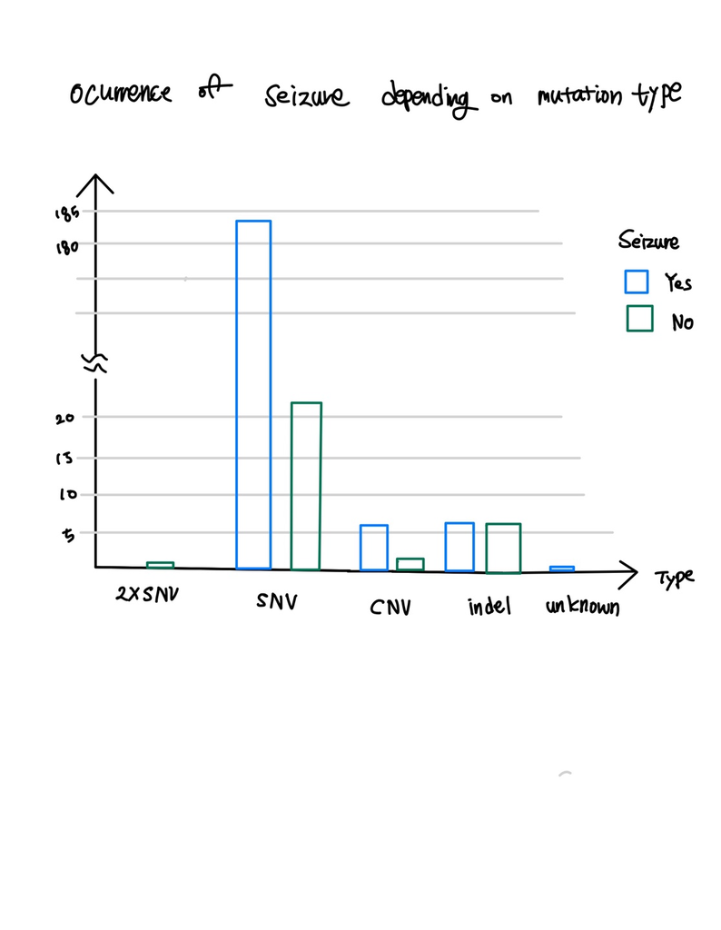

```r
library(knitr)
knitr::include_graphics("/Users/ddw20/Pictures/Saved Pictures/plot.jpg")
```